# ME613 - Análise de Regressão

## Multicolinearidade

## Introdução

Vamos considerar o modelo de regressão linear múltipla:

\[Y_i = \beta_1 X_{i1} + \beta_2 X_{i2} + \epsilon_i, \;\; i = 1,\dots, n, \;\; \epsilon_i \; iid \; \sim N(0, \sigma^2)\] em que \(X_1\) e \(X_2\) são variáveis tranformadas via transformação de correlação (ou seja estão centradas no 0 e limitadas entre -1 e 1).

A matrix de desenho do modelo é data por

\[\mathbf{X}=\left( \begin{array}{cc} X_{11} & X_{12} \\ X_{21} & X_{22} \\ \vdots & \vdots \\ X_{n1} & X_{n2} \end{array} \right) \;\; e \;\; \mathbf{X}^T\mathbf{X}=\left( \begin{array}{ccccc} \sum X^2_{i1} & \sum X_{i1} X_{i2} \\ \sum X_{i1} X_{i2} & \sum X^2_{i2} \\ \end{array} \right) \] Daí temos que

\[\det(\mathbf{X}^T\mathbf{X}) = \sum X^2_{i1}\sum X^2_{i2} - (\sum X_{i1} X_{i2})^2\]

Se \(X_1\) e \(X_2\) são não colineares então temos que \(\sum X_{i1} X_{i2}=0\) e a matrix \(\mathbf{X}^T\mathbf{X} = diag({\sum X^2_{i1},\sum X^2_{i2}})\).

Daí temos que

\[\hat{\mathbf{\beta}} = (\mathbf{X}^T\mathbf{X})^{-1} \mathbf{X}^T \mathbf{Y} = \left( \begin{array}{cc} \frac{\sum X_{i1} Y_i}{\sum X^2_{i1}} \\ \frac{\sum X_{i2} Y_i}{\sum X^2_{i2}} \end{array} \right) \]

E neste caso obter os estimadoes para \(\beta_1\) e \(\beta_2\) na regressão múltipla é equivalente a estimá-los separadamente via modelos de regressão linear simples independentes; e

\(SQReg(X_1\mid X_2)=SQReg(X_1)\) e \(SQReg(X_2\mid X_1)=SQReg(X_2)\)

Por outro lado se \(X_1\) e \(X_2\) são perfeitamente correlacionadas então

\[ \sum X^2_{i1} \sum X^2_{i2} = (\sum X_{i1} X_{i2})^2 \; e \;\]

\[\det(\mathbf{X}^T\mathbf{X}) = 0\]

Neste caso não é possível obter a matriz \(\mathbf{X}^T\mathbf{X}\) e o sistema de equações normais não possue solução única.

Quanto mais próximo de 1 for a correlação entre as variáveis mais próximo de 0 será o \(\det(\mathbf{X}^T\mathbf{X}) = 0\)

## Exemplo

\(X_1\): tamanho da equipe ; \(X_2\): pagamento (dólares) ; e \(Y\): produtividade .

```r
dados = read.table('./dados/CH07TA06.txt')
colnames(dados) <- c("X1","X2","Y")
dados
```

```
##   X1 X2  Y
## 1  4  2 42
## 2  4  2 39
## 3  4  3 48
## 4  4  3 51
## 5  6  2 49
## 6  6  2 53
## 7  6  3 61
## 8  6  3 60
```

```r
cor(dados$X1, dados$X2)
```

```
## [1] 0
```

Regressão de \(Y\) em \(X_1\): \(\hat{\beta}_1\).

```
##             Estimate Std. Error  t value   Pr(>|t|)
## (Intercept)   23.500  10.111359 2.324119 0.05911468
## X1             5.375   1.983001 2.710539 0.03508095
```

```
## Analysis of Variance Table
##
## Response: Y
##           Df Sum Sq Mean Sq F value  Pr(>F)
## X1         1 231.12 231.125   7.347 0.03508 *
## Residuals  6 188.75  31.458
## ---
## Signif. codes:  0 '***' 0.001 '**' 0.01 '*' 0.05 '.' 0.1 ' ' 1
```

\[\hat{\beta}_1=5.375\]

\[SQReg(X_1)=231.12\]

Regressão de \(Y\) em \(X_2\): \(\hat{\beta}_2\).

```
##             Estimate Std. Error  t value   Pr(>|t|)
## (Intercept)    27.25  11.607738 2.347572 0.05724814
## X2              9.25   4.552929 2.031659 0.08846031
```

```
## Analysis of Variance Table
##
## Response: Y
##           Df Sum Sq Mean Sq F value  Pr(>F)
## X2         1 171.12 171.125  4.1276 0.08846 .
## Residuals  6 248.75  41.458
## ---
## Signif. codes:  0 '***' 0.001 '**' 0.01 '*' 0.05 '.' 0.1 ' ' 1
```

\[\hat{\beta}_2=9.25\]

\[SQReg(X_2)=171.12\]

Regressão de \(Y\) em \(X_1\) e \(X_2\): \(\hat{\beta}^*_1\) e \(\hat{\beta}^*_2\).

```
##             Estimate Std. Error   t value     Pr(>|t|)
## (Intercept)    0.375  4.7404509 0.0791064 0.9400164184
## X1             5.375  0.6637959 8.0973685 0.0004657066
## X2             9.250  1.3275918 6.9675031 0.0009365829
```

\[\hat{\beta}_1^*=5.375\]

\[\hat{\beta}_2^*=9.25\]

```
## Analysis of Variance Table
##
## Response: Y
##           Df  Sum Sq Mean Sq F value    Pr(>F)
## X1         1 231.125 231.125  65.567 0.0004657 ***
## X2         1 171.125 171.125  48.546 0.0009366 ***
## Residuals  5  17.625   3.525
## ---
## Signif. codes:  0 '***' 0.001 '**' 0.01 '*' 0.05 '.' 0.1 ' ' 1
```

```
## Analysis of Variance Table
##
## Response: Y
##           Df  Sum Sq Mean Sq F value    Pr(>F)
## X2         1 171.125 171.125  48.546 0.0009366 ***
## X1         1 231.125 231.125  65.567 0.0004657 ***
## Residuals  5  17.625   3.525
## ---
## Signif. codes:  0 '***' 0.001 '**' 0.01 '*' 0.05 '.' 0.1 ' ' 1
```

## Exemplo 2

```r
dados = read.table('./dados/CH07TA08.txt')
colnames(dados) <- c("X1","X2","Y")
dados
```

```
##   X1 X2   Y
## 1  2  6  23
## 2  8  9  83
## 3  6  8  63
## 4 10 10 103
```

```r
cor(dados$X1, dados$X2)
```

```
## [1] 1
```

```r
modelo1 <- lm(Y ~ X1 + X2,data=dados)
summary(modelo1)$coef
```

```
##             Estimate   Std. Error      t value     Pr(>|t|)
## (Intercept)        3 6.064937e-15 4.946465e+14 4.087051e-30
## X1                10 8.492610e-16 1.177494e+16 7.212443e-33
```

que produz valores ajustados perfeitos (resíduo nulo):

```
##   1   2   3   4
##  23  83  63 103
```

\[\hat{Y}=-87 + X_1 + 18 X_2\]

\[\hat{Y}=-7+9X_1+2X_2\]

também fornecem os mesmos valores para \(\hat{Y}\).

Problema: \(X_1\) e \(X_2\) são perfeitamente correlacionadas (\(X_2=5+0.5X_1\)).

Podemos obter bons valores ajustados/preditos, mas não podemos interpretar os parâmetros do modelo (pois temos infinitas possibilidades).

## Efeitos da multicolinearidade

Na prática, dificilmente encontraremos variáveis preditoras que sejam perfeitamente correlacionadas entre si.

No entanto, quando a correlação é alta, temos problemas similares aos vistos no exemplo anterior.

## Efeito nos coeficientes de regressão

\(X_1\): tríceps

\(X_2\): coxa

\(X_3\): antebraço

\(Y\): gordura corporal

```
##      X1   X2   X3    Y
## 1  19.5 43.1 29.1 11.9
## 2  24.7 49.8 28.2 22.8
## 3  30.7 51.9 37.0 18.7
## 4  29.8 54.3 31.1 20.1
## 5  19.1 42.2 30.9 12.9
## 6  25.6 53.9 23.7 21.7
## 7  31.4 58.5 27.6 27.1
## 8  27.9 52.1 30.6 25.4
## 9  22.1 49.9 23.2 21.3
## 10 25.5 53.5 24.8 19.3
## 11 31.1 56.6 30.0 25.4
## 12 30.4 56.7 28.3 27.2
## 13 18.7 46.5 23.0 11.7
## 14 19.7 44.2 28.6 17.8
## 15 14.6 42.7 21.3 12.8
## 16 29.5 54.4 30.1 23.9
## 17 27.7 55.3 25.7 22.6
## 18 30.2 58.6 24.6 25.4
## 19 22.7 48.2 27.1 14.8
## 20 25.2 51.0 27.5 21.1
```

## Exemplo

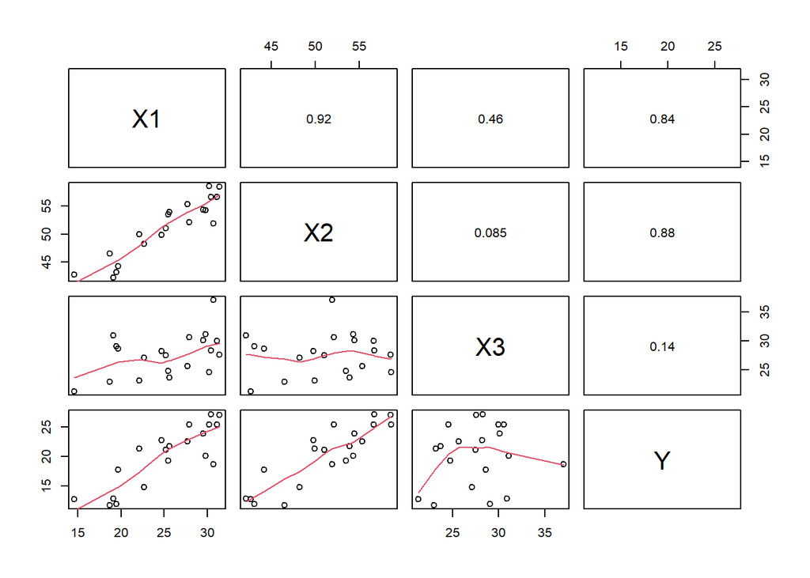

## Exemplo

Quando as preditoras têm correlação, os efeitos das variáveis são marginais ou parciais.

| Variável no modelo | \(\hat{\beta}_1\) | \(\hat{\beta}_2\) |
| --- | --- | --- |
| \(X_1\) | 0.857 |  |
| \(X_2\) |  | 0.857 |
| \(X_1\), \(X_2\) | 0.222 | 0.659 |
| \(X_1\), \(X_2\), \(X_3\) | 4.334 | -2.857 |

As estimativas do efeito de \(X_1\) no modelo variam muito, dependendo das variáveis que são consideradas nos modelos. O mesmo pode ser dito sobre o efeito de \(X_2\).

## Efeito na soma extra de quadrados

Quando as variáveis preditoras apresentam correlação, a contribuição marginal de cada variável na redução da soma de quadrados do erro varia, dependendo de quais variáveis já estão no modelo.

Por exemplo: considerando apenas \(X_1\) no modelo

```
## Analysis of Variance Table
##
## Response: Y
##           Df Sum Sq Mean Sq F value    Pr(>F)
## X1         1 352.27  352.27  44.305 3.024e-06 ***
## Residuals 18 143.12    7.95
## ---
## Signif. codes:  0 '***' 0.001 '**' 0.01 '*' 0.05 '.' 0.1 ' ' 1
```

\[SQReg(X_1)=352.27\]

## Exemplo

Considerando \(X_1\) e \(X_2\) no modelo (primeiro \(X_2\) e depois \(X_1\)):

```
## Analysis of Variance Table
##
## Response: Y
##           Df Sum Sq Mean Sq F value    Pr(>F)
## X2         1 381.97  381.97  59.057 6.281e-07 ***
## X1         1   3.47    3.47   0.537    0.4737
## Residuals 17 109.95    6.47
## ---
## Signif. codes:  0 '***' 0.001 '**' 0.01 '*' 0.05 '.' 0.1 ' ' 1
```

\[SQReg(X_1\mid X_2)=3.473\]

## Exemplo

O modelo de \(SQReg(X_1\mid X_1)\) ser tão pequeno quando comparado a \(SQReg(X_1)\) é a alta correlação entre \(X_1\) e \(X_2\) (0.92) e de cada uma delas com a variável resposta (0.84 e 0.88, respectivamente).

Desta forma, quando \(X_2\) já está no modelo, a contribuição marginal de \(X_1\) é pequena na redução da soma de quadrados do erro, pois \(X_2\) contém praticamente a mesma informação que \(X_1\).

## Efeito no desvio-padrão da estimativa

| Variável no modelo | \(\hat{\beta}_1\) | \(\hat{\beta}_2\) |
| --- | --- | --- |
| \(X_1\) | 0.129 |  |
| \(X_2\) |  | 0.11 |
| \(X_1\), \(X_2\) | 0.303 | 0.291 |
| \(X_1\), \(X_2\), \(X_3\) | 3.016 | 2.582 |

## Efeito nos valores ajustados e preditos

| Variável no modelo | \(QME\) |
| --- | --- |
| \(X_1\) | 7.95 |
| \(X_1\), \(X_2\) | 6.47 |
| \(X_1\), \(X_2\), \(X_3\) | 6.15 |

\(QME\) diminui conforme variáveis são adicionadas ao modelo (caso usual).

## Efeito nos valores ajustados e preditos

A precisão do valor ajustado não é tão afetada quando inserimos ou não uma variável preditora muito correlacionada com outra já no modelo.

Por exemplo, se considerarmos apenas o modelo com \(X_1\), o valor estimado de gorduta corporal para \(X_1=25\) é:

\[\hat{Y}=19.934\quad\quad\sqrt{\widehat{Var(\hat{Y})}}=0.632\]

Quando incluímos \(X_2\), altamente correlacionada à \(X_1\), temos:

\[\hat{Y}=19.356\quad\quad\sqrt{\widehat{Var(\hat{Y})}}=0.624\]

quando \(X_1=25\) e \(X_2=50\), por exemplo.

## Efeito nos testes simultâneos de \(\beta_k\)

Considere os dados sobre gordura corporal e o modelo com \(X_1\) e \(X_2\) no modelo.

Queremos testar \(H_0\): \(\beta_1=\beta_2=0\).

Calculamos:

\[t_1=\frac{\hat{\beta}_1}{\sqrt{\widehat{Var}(\hat{\beta}_1)}}\quad\quad t_2=\frac{\hat{\beta}_2}{\sqrt{\widehat{Var}(\hat{\beta}_2)}}\]

e não rejeitamos \(H_0\) se ambos \(|t_1|\) e \(|t_2|\) forem menores do que \(t_{n-3,\alpha/4}=2.46\)

para \(\alpha=0.05\).

## Exemplo

```
##
## Call:
## lm(formula = Y ~ X1 + X2, data = dat)
##
## Residuals:
##     Min      1Q  Median      3Q     Max
## -3.9469 -1.8807  0.1678  1.3367  4.0147
##
## Coefficients:
##             Estimate Std. Error t value Pr(>|t|)
## (Intercept) -19.1742     8.3606  -2.293   0.0348 *
## X1            0.2224     0.3034   0.733   0.4737
## X2            0.6594     0.2912   2.265   0.0369 *
## ---
## Signif. codes:  0 '***' 0.001 '**' 0.01 '*' 0.05 '.' 0.1 ' ' 1
##
## Residual standard error: 2.543 on 17 degrees of freedom
## Multiple R-squared:  0.7781, Adjusted R-squared:  0.7519
## F-statistic:  29.8 on 2 and 17 DF,  p-value: 2.774e-06
```

Não rejeitamos \(H_0\).

## Exemplo

```
## Analysis of Variance Table
##
## Response: Y
##           Df Sum Sq Mean Sq F value    Pr(>F)
## X1         1 352.27  352.27 54.4661 1.075e-06 ***
## X2         1  33.17   33.17  5.1284    0.0369 *
## Residuals 17 109.95    6.47
## ---
## Signif. codes:  0 '***' 0.001 '**' 0.01 '*' 0.05 '.' 0.1 ' ' 1
```

```
## Analysis of Variance Table
##
## Model 1: Y ~ 1
## Model 2: Y ~ X1 + X2
##   Res.Df    RSS Df Sum of Sq      F    Pr(>F)
## 1     19 495.39
## 2     17 109.95  2    385.44 29.797 2.774e-06 ***
## ---
## Signif. codes:  0 '***' 0.001 '**' 0.01 '*' 0.05 '.' 0.1 ' ' 1
```

## Exemplo

Se utilizarmos o teste \(F\) para \(H_0:\beta_1=\beta_2=0\), temos:

\[F_{obs}=\frac{QMReg}{QME}=\frac{385.44/2}{109.95/17}=29.8\]

Sob \(H_0\) a estatística do teste tem distribuição \(F(2,17)\), de maneira que o valor crítico para \(\alpha=0.05\) é \(3.59\).

Encontramos evidências para rejeitar \(H_0\).

Resultado contrário ao obtido com os testes \(t\) com correção de Bonferroni.

## Agradecimento

- Slides criados por Samara F Kiihl / IMECC / UNICAMP

## Leitura

- Applied Linear Statistical Models: Seção 7.6.
- Faraway - [Linear Models with R](http://www.maths.bath.ac.uk/~jjf23/LMR/): Seção 7.3.

[figure not shown]